# READy Exercise Part 3

**Authors**

- Riley Herber
- Marco Reina

**Author affiliations**

1. University of Georgia, Athens, GA, USA.

$\dagger$ Disclaimer: The opinions expressed in this article are the author’s own and don’t reflect their employer.

# 1 Summary/Abstract

This project examines the relationship between individuals height, weight, gender, age, and blood type to identify any significant correlations between these variables.

Linear Models were created using these variables to try to identify significant findings. Multiple tables and figures display these relationships.

# 2 Introduction

## 2.1 Description of data and data source

There are five variables in this dataset. Height and weight are numerical values. Gender is a categorical value written as M, F, or O.

The Blood Type variable denotes the blood type symbol (A, B, AB, or O) that the individual has. The Age variable denotes the individual’s age in years as a numeric value, which was randomly generated from 18-80.

# 3 Methods

## 3.1 Data acquisition

The raw data of Height, Weight, and Gender was given by our professor Dr. Andreas Handel, while the Age variable was generated using a random number generator between 18-80, and the blood type variable was randomly assigned in a A, B, AB, O cycling order.

## 3.2 Data import and cleaning

The data was cleaned by removing any NA variables, and converting all values into appropriate data types.

## 3.3 Statistical analysis

The analysis was done by fitting multiple linear models with height as the outcome with varying predictor variables. The summaries of these models were recorded and observed.

# 4 Results

## 4.1 Exploratory/Descriptive analysis

For Exploratory analysis, we made plots and tables for the most interesting/important quantities in the data.

Table 1 shows a summary of the data.

Table 1: Data table summary table.

| skim_type | skim_variable | n_missing | complete_rate | character.min | character.max | character.empty | character.n_unique | character.whitespace | factor.ordered | factor.n_unique | factor.top_counts | numeric.mean | numeric.sd | numeric.p0 | numeric.p25 | numeric.p50 | numeric.p75 | numeric.p100 | numeric.hist |
| --- | --- | --- | --- | --- | --- | --- | --- | --- | --- | --- | --- | --- | --- | --- | --- | --- | --- | --- | --- |
| character | Blood Type | 0 | 1 | 1 | 2 | 0 | 4 | 0 | NA | NA | NA | NA | NA | NA | NA | NA | NA | NA | NA |
| factor | Gender | 0 | 1 | NA | NA | NA | NA | NA | FALSE | 3 | M: 4, F: 3, O: 2 | NA | NA | NA | NA | NA | NA | NA | NA |
| numeric | Height | 0 | 1 | NA | NA | NA | NA | NA | NA | NA | NA | 165.66667 | 15.97655 | 133 | 156 | 166 | 178 | 183 | ▂▁▃▃▇ |
| numeric | Weight | 0 | 1 | NA | NA | NA | NA | NA | NA | NA | NA | 70.11111 | 21.24526 | 45 | 55 | 70 | 80 | 110 | ▇▂▃▂▂ |
| numeric | Age | 0 | 1 | NA | NA | NA | NA | NA | NA | NA | NA | 43.55556 | 17.95906 | 21 | 25 | 44 | 61 | 63 | ▆▂▂▁▇ |

Figure 1 shows a histogram of the Variable Height

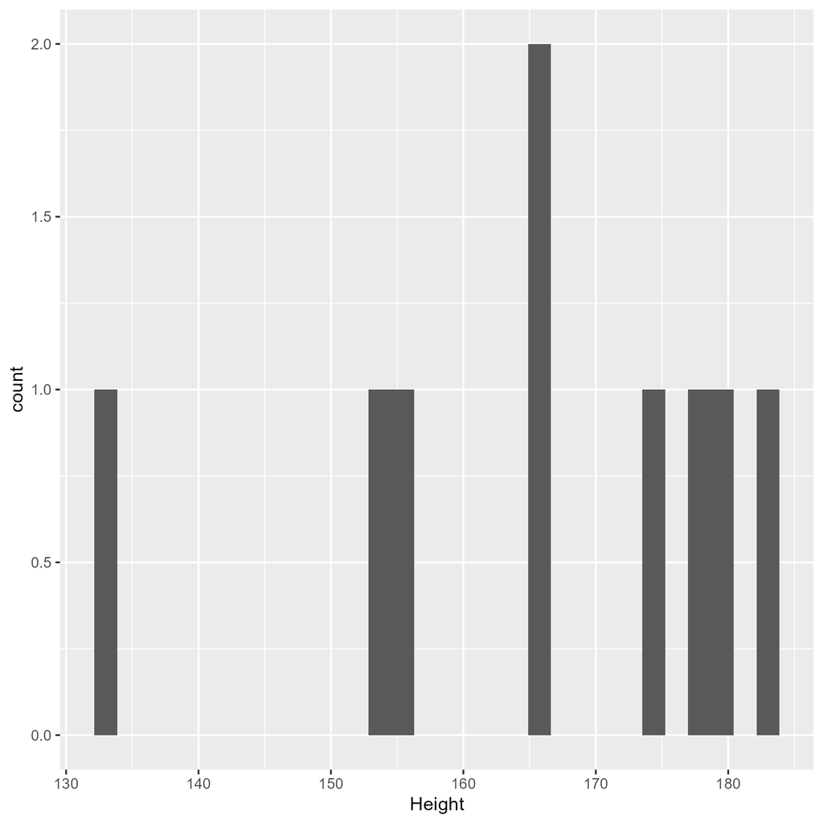

Figure 1: Height Distribution.

Figure 2 shows a histogram of the variable Weight

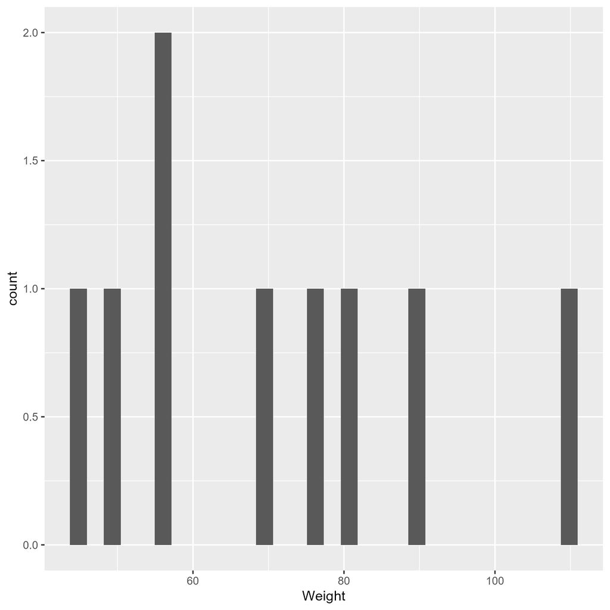

Figure 2: Weight Distribution

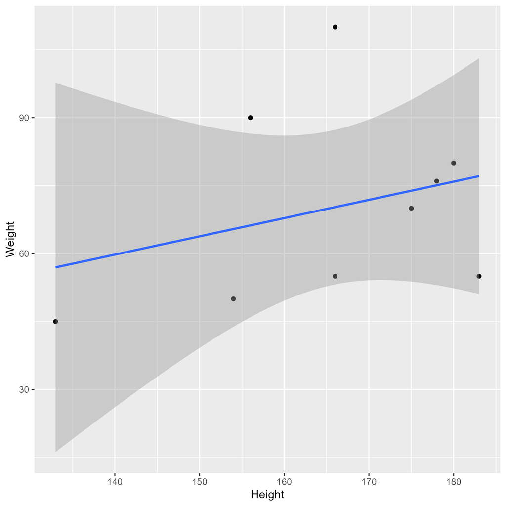

[figure not shown]

Figure 5 is a boxplot with Blood Type on the x-axis, and height on the y-axis.

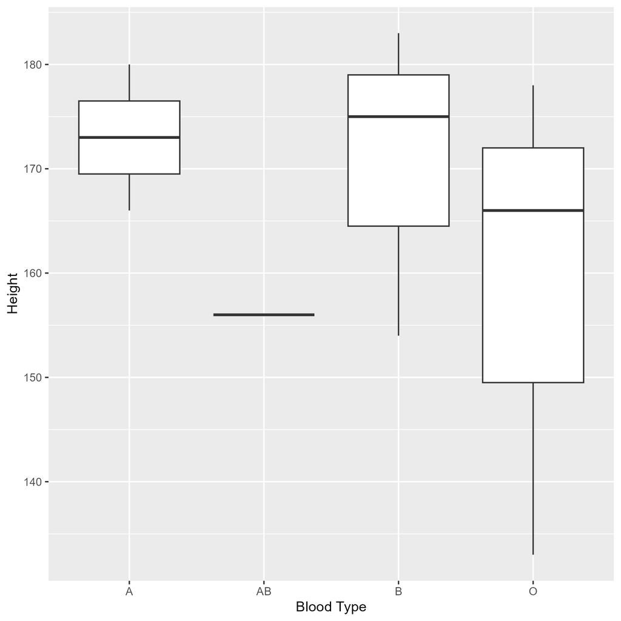

Figure 5: Boxplot with Blood Type on the x-axis, and height on the y-axis.

Figure 6 is a scatterplot with weight on the x-axis and Age on the y-axis

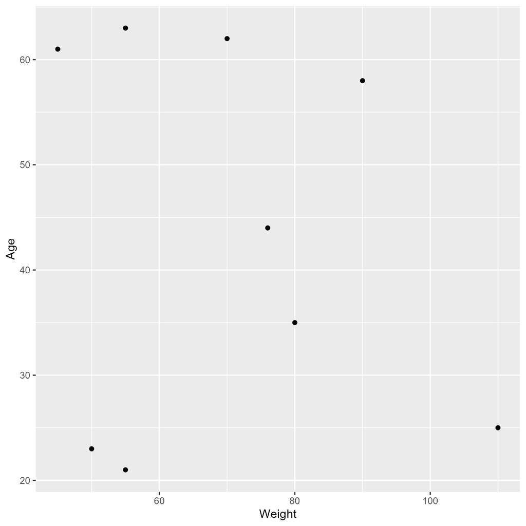

Figure 6: Scatterplot with weight on the x-axis and Age on the y-axis.

## 4.2 Basic statistical analysis

Linear Models were run using height as the outcome, and other variables as predictors to try to identify significant findings.

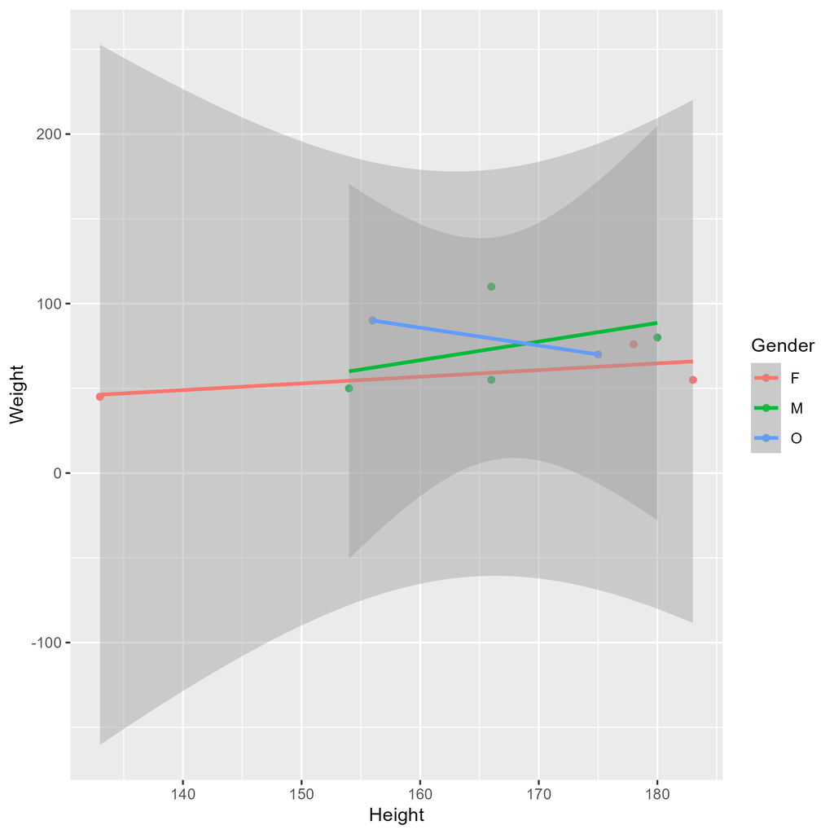

Figure 7: Height and weight stratified by gender.

## 4.3 Full analysis

Table 2 shows a summary of a fit linear model using height as outcome, weight as predictor.

Table 2: Linear model fit using height as outcome, weight as predictor table.

| term | estimate | std.error | statistic | p.value |
| --- | --- | --- | --- | --- |
| (Intercept) | 149.6997661 | 19.7518528 | 7.5790240 | 0.0001285 |
| Weight | 0.2277371 | 0.2708841 | 0.8407177 | 0.4282860 |

Table 3 shows a summary of a linear model fit linear model using height as outcome, weight and gender as predictor.

Table 3: Linear model fit using height as outcome, weight and gender as predictor table.

| term | estimate | std.error | statistic | p.value |
| --- | --- | --- | --- | --- |
| (Intercept) | 149.2726967 | 23.3823360 | 6.3839942 | 0.0013962 |
| Weight | 0.2623972 | 0.3512436 | 0.7470519 | 0.4886517 |
| GenderM | -2.1244913 | 15.5488953 | -0.1366329 | 0.8966520 |
| GenderO | -4.7644739 | 19.0114155 | -0.2506112 | 0.8120871 |

[output not shown]